# SK_02_BOND_PROCEED_REFUND_ADVC_X

Bonds were issued as part of a refunding issue of taxable bonds or an advance refunding issue [x] · Checkbox report

## Overview

**Description**

Advance refunding?

**Table**

`SK-P02-T01-BOND-PROCEEDS` (many)

**Location code**

`SCHED-K-PART-02-LINE-15`

**Family**

`SCHED-K-PART-02-LINE-15`

**Data type**

checkbox (xsd: BooleanType)

**Scope**

PC

**Status**

unreviewed

4

xpaths mapped (4 observed)

126,539

filings with a value

2009–2024

tax years observed

5

open flags (1 errors)

## Flags

| Severity | Flag | Xpath | Detail |
| --- | --- | --- | --- |
| ⚠ error | `COLLISION` | IRS990ScheduleK/TaxExemptBondsProceedsGrp/RefundingTaxExemptBondsInd | 38628 filings contain 2+ of its xpaths; most common set: /Return/ReturnData/IRS990ScheduleK/TaxExemptBondsProceedsGrp/RefundingTaxExemptBondsInd ; /Return/ReturnData/IRS990ScheduleK/TaxExemptBondsProc… |
| ⓘ info | `MANY_NOT_REPEATING` | IRS990ScheduleK/TaxExemptBondsProceedsGrp/RefundingTaxExemptBondsInd | many-to-one table, but 58% of values sit in no repeating element |
| ⓘ info | `MANY_NOT_REPEATING` | IRS990ScheduleK/TaxExemptBondsProceedsGrp/RefundingTaxableBondsInd | many-to-one table, but 58% of values sit in no repeating element |
| ⓘ info | `MANY_NOT_REPEATING` | IRS990ScheduleK/TaxExemptBondsProceedsGrp/AdvanceRefundingInd | many-to-one table, but 57% of values sit in no repeating element |
| ⓘ info | `MANY_NOT_REPEATING` | IRS990ScheduleK/Form990ScheduleKPartII/AdvanceRefunding | many-to-one table, but 57% of values sit in no repeating element |

## Xpaths

All mapped xpaths (under /Return/ReturnData or /Return/ReturnHeader), oldest first. Charts label each series by its xpath.

| Xpath | Form | Chart label | First year | Last year | Versions | Filings | Repeats in |
| --- | --- | --- | --- | --- | --- | --- | --- |
| IRS990ScheduleK/Form990ScheduleKPartII/AdvanceRefunding | Sched K | same | 2009 | 2012 | 17 | 19,186 | 41.2% |
| IRS990ScheduleK/TaxExemptBondsProceedsGrp/AdvanceRefundingInd | Sched K | …90ScheduleK/TaxExemptBondsProceedsGrp/AdvanceRefundingInd | 2013 | 2017 | 13 | 30,052 | 41.1% |
| IRS990ScheduleK/TaxExemptBondsProceedsGrp/RefundingTaxExemptBondsInd | Sched K | …uleK/TaxExemptBondsProceedsGrp/RefundingTaxExemptBondsInd | 2018 | 2024 | 24 | 38,672 | 40.4% |
| IRS990ScheduleK/TaxExemptBondsProceedsGrp/RefundingTaxableBondsInd | Sched K | …eduleK/TaxExemptBondsProceedsGrp/RefundingTaxableBondsInd | 2018 | 2024 | 24 | 38,629 | 40.4% |

## Coverage

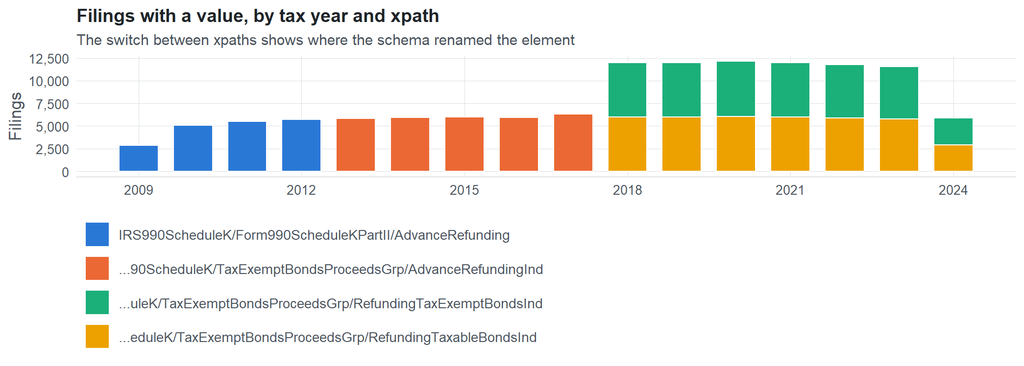

**Table view**

Table view: filings by tax year and series

| Tax year | IRS990ScheduleK/Form990ScheduleKPartII/AdvanceRefunding | …90ScheduleK/TaxExemptBondsProceedsGrp/AdvanceRefundingInd | …uleK/TaxExemptBondsProceedsGrp/RefundingTaxExemptBondsInd | …eduleK/TaxExemptBondsProceedsGrp/RefundingTaxableBondsInd |
| --- | --- | --- | --- | --- |
| 2009 | 2,861 | 0 | 0 | 0 |
| 2010 | 5,082 | 0 | 0 | 0 |
| 2011 | 5,497 | 0 | 0 | 0 |
| 2012 | 5,746 | 0 | 0 | 0 |
| 2013 | 0 | 5,823 | 0 | 0 |
| 2014 | 0 | 5,954 | 0 | 0 |
| 2015 | 0 | 5,980 | 0 | 0 |
| 2016 | 0 | 5,968 | 0 | 0 |
| 2017 | 0 | 6,327 | 0 | 0 |
| 2018 | 0 | 0 | 5,990 | 5,985 |
| 2019 | 0 | 0 | 5,993 | 5,988 |
| 2020 | 0 | 0 | 6,079 | 6,073 |
| 2021 | 0 | 0 | 5,989 | 5,982 |
| 2022 | 0 | 0 | 5,893 | 5,884 |
| 2023 | 0 | 0 | 5,781 | 5,773 |
| 2024 | 0 | 0 | 2,947 | 2,944 |

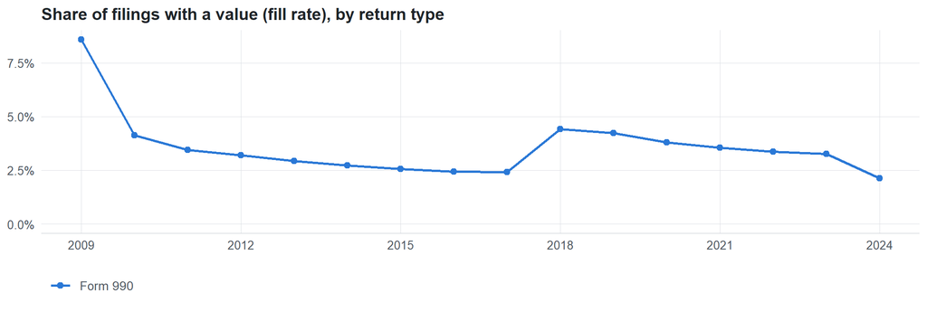

**Table view**

Table view: fill rate

| Tax year | Return type | Filings | All filings | Fill rate |
| --- | --- | --- | --- | --- |
| 2009 | Form 990 | 2,861 | 33,311 | 8.59% |
| 2010 | Form 990 | 5,082 | 123,025 | 4.13% |
| 2011 | Form 990 | 5,497 | 159,504 | 3.45% |
| 2012 | Form 990 | 5,746 | 179,688 | 3.20% |
| 2013 | Form 990 | 5,823 | 198,855 | 2.93% |
| 2014 | Form 990 | 5,954 | 218,619 | 2.72% |
| 2015 | Form 990 | 5,980 | 233,519 | 2.56% |
| 2016 | Form 990 | 5,968 | 243,903 | 2.45% |
| 2017 | Form 990 | 6,327 | 261,612 | 2.42% |
| 2018 | Form 990 | 11,975 | 271,442 | 4.41% |
| 2019 | Form 990 | 11,981 | 283,694 | 4.22% |
| 2020 | Form 990 | 12,152 | 320,342 | 3.79% |
| 2021 | Form 990 | 11,971 | 336,480 | 3.56% |
| 2022 | Form 990 | 11,777 | 349,055 | 3.37% |
| 2023 | Form 990 | 11,554 | 354,768 | 3.26% |
| 2024 | Form 990 | 5,891 | 277,298 | 2.12% |

## Repeating groups

Table cardinality in the concordance: **many**. 4 of 4 observed xpaths repeat within a filing.

Repeating element each xpath was observed in (from the raw indexed xpath)

| Xpath | Repeating element | Filings (summed over years) |
| --- | --- | --- |
| IRS990ScheduleK/Form990ScheduleKPartII/AdvanceRefunding | (none) | 11267 |
| IRS990ScheduleK/Form990ScheduleKPartII/AdvanceRefunding | IRS990ScheduleK | 479 |
| IRS990ScheduleK/Form990ScheduleKPartII/AdvanceRefunding | IRS990ScheduleK/Form990ScheduleKPartII | 7888 |
| IRS990ScheduleK/TaxExemptBondsProceedsGrp/AdvanceRefundingInd | (none) | 17662 |
| IRS990ScheduleK/TaxExemptBondsProceedsGrp/AdvanceRefundingInd | IRS990ScheduleK | 973 |
| IRS990ScheduleK/TaxExemptBondsProceedsGrp/AdvanceRefundingInd | IRS990ScheduleK/TaxExemptBondsProceedsGrp | 12362 |
| IRS990ScheduleK/TaxExemptBondsProceedsGrp/RefundingTaxExemptBondsInd | (none) | 23005 |
| IRS990ScheduleK/TaxExemptBondsProceedsGrp/RefundingTaxExemptBondsInd | IRS990ScheduleK | 1268 |
| IRS990ScheduleK/TaxExemptBondsProceedsGrp/RefundingTaxExemptBondsInd | IRS990ScheduleK/TaxExemptBondsProceedsGrp | 15646 |
| IRS990ScheduleK/TaxExemptBondsProceedsGrp/RefundingTaxableBondsInd | (none) | 22975 |
| IRS990ScheduleK/TaxExemptBondsProceedsGrp/RefundingTaxableBondsInd | IRS990ScheduleK | 1267 |
| IRS990ScheduleK/TaxExemptBondsProceedsGrp/RefundingTaxableBondsInd | IRS990ScheduleK/TaxExemptBondsProceedsGrp | 15633 |

## Values

| Result | Check | Detail |
| --- | --- | --- |
| ✓ pass | Values are checkbox codes | 100.0% of values are X / true / false / 1 / 0 |
| ⓘ info | Meaning of a blank | 74% of values are explicit false/0, so a missing value is not the same as unchecked |
| ✓ pass | Element names agree in polarity | all element names have the same polarity |

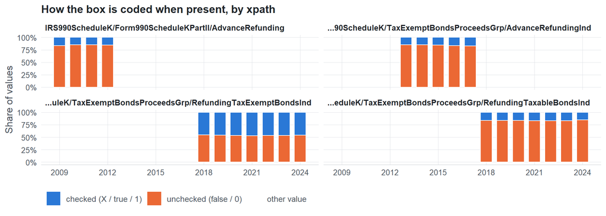

**Table view**

Table view: value coding by tax year

| Series | Tax year | Code | Filings | Share |
| --- | --- | --- | --- | --- |
| IRS990ScheduleK/Form990ScheduleKPartII/AdvanceRefunding | 2009 | checked (X / true / 1) | 520 | 16.4% |
| IRS990ScheduleK/Form990ScheduleKPartII/AdvanceRefunding | 2009 | unchecked (false / 0) | 2,655 | 83.6% |
| IRS990ScheduleK/Form990ScheduleKPartII/AdvanceRefunding | 2010 | checked (X / true / 1) | 835 | 15.0% |
| IRS990ScheduleK/Form990ScheduleKPartII/AdvanceRefunding | 2010 | unchecked (false / 0) | 4,725 | 85.0% |
| IRS990ScheduleK/Form990ScheduleKPartII/AdvanceRefunding | 2011 | checked (X / true / 1) | 892 | 14.8% |
| IRS990ScheduleK/Form990ScheduleKPartII/AdvanceRefunding | 2011 | unchecked (false / 0) | 5,120 | 85.2% |
| IRS990ScheduleK/Form990ScheduleKPartII/AdvanceRefunding | 2012 | checked (X / true / 1) | 965 | 15.3% |
| IRS990ScheduleK/Form990ScheduleKPartII/AdvanceRefunding | 2012 | unchecked (false / 0) | 5,352 | 84.7% |
| …90ScheduleK/TaxExemptBondsProceedsGrp/AdvanceRefundingInd | 2013 | checked (X / true / 1) | 954 | 14.9% |
| …90ScheduleK/TaxExemptBondsProceedsGrp/AdvanceRefundingInd | 2013 | unchecked (false / 0) | 5,460 | 85.1% |
| …90ScheduleK/TaxExemptBondsProceedsGrp/AdvanceRefundingInd | 2014 | checked (X / true / 1) | 992 | 15.1% |
| …90ScheduleK/TaxExemptBondsProceedsGrp/AdvanceRefundingInd | 2014 | unchecked (false / 0) | 5,580 | 84.9% |
| …90ScheduleK/TaxExemptBondsProceedsGrp/AdvanceRefundingInd | 2015 | checked (X / true / 1) | 1,035 | 15.6% |
| …90ScheduleK/TaxExemptBondsProceedsGrp/AdvanceRefundingInd | 2015 | unchecked (false / 0) | 5,591 | 84.4% |
| …90ScheduleK/TaxExemptBondsProceedsGrp/AdvanceRefundingInd | 2016 | checked (X / true / 1) | 1,091 | 16.4% |
| …90ScheduleK/TaxExemptBondsProceedsGrp/AdvanceRefundingInd | 2016 | unchecked (false / 0) | 5,555 | 83.6% |
| …90ScheduleK/TaxExemptBondsProceedsGrp/AdvanceRefundingInd | 2017 | checked (X / true / 1) | 1,204 | 17.0% |
| …90ScheduleK/TaxExemptBondsProceedsGrp/AdvanceRefundingInd | 2017 | unchecked (false / 0) | 5,878 | 83.0% |
| …uleK/TaxExemptBondsProceedsGrp/RefundingTaxExemptBondsInd | 2018 | checked (X / true / 1) | 3,276 | 45.6% |
| …uleK/TaxExemptBondsProceedsGrp/RefundingTaxExemptBondsInd | 2018 | unchecked (false / 0) | 3,911 | 54.4% |
| …uleK/TaxExemptBondsProceedsGrp/RefundingTaxExemptBondsInd | 2019 | checked (X / true / 1) | 3,315 | 46.1% |
| …uleK/TaxExemptBondsProceedsGrp/RefundingTaxExemptBondsInd | 2019 | unchecked (false / 0) | 3,883 | 53.9% |
| …uleK/TaxExemptBondsProceedsGrp/RefundingTaxExemptBondsInd | 2020 | checked (X / true / 1) | 3,381 | 46.4% |
| …uleK/TaxExemptBondsProceedsGrp/RefundingTaxExemptBondsInd | 2020 | unchecked (false / 0) | 3,898 | 53.6% |
| …uleK/TaxExemptBondsProceedsGrp/RefundingTaxExemptBondsInd | 2021 | checked (X / true / 1) | 3,375 | 47.1% |
| …uleK/TaxExemptBondsProceedsGrp/RefundingTaxExemptBondsInd | 2021 | unchecked (false / 0) | 3,791 | 52.9% |
| …uleK/TaxExemptBondsProceedsGrp/RefundingTaxExemptBondsInd | 2022 | checked (X / true / 1) | 3,306 | 46.8% |
| …uleK/TaxExemptBondsProceedsGrp/RefundingTaxExemptBondsInd | 2022 | unchecked (false / 0) | 3,764 | 53.2% |
| …uleK/TaxExemptBondsProceedsGrp/RefundingTaxExemptBondsInd | 2023 | checked (X / true / 1) | 3,229 | 46.3% |
| …uleK/TaxExemptBondsProceedsGrp/RefundingTaxExemptBondsInd | 2023 | unchecked (false / 0) | 3,740 | 53.7% |
| …uleK/TaxExemptBondsProceedsGrp/RefundingTaxExemptBondsInd | 2024 | checked (X / true / 1) | 1,604 | 46.0% |
| …uleK/TaxExemptBondsProceedsGrp/RefundingTaxExemptBondsInd | 2024 | unchecked (false / 0) | 1,881 | 54.0% |
| …eduleK/TaxExemptBondsProceedsGrp/RefundingTaxableBondsInd | 2018 | checked (X / true / 1) | 1,101 | 16.5% |
| …eduleK/TaxExemptBondsProceedsGrp/RefundingTaxableBondsInd | 2018 | unchecked (false / 0) | 5,558 | 83.5% |
| …eduleK/TaxExemptBondsProceedsGrp/RefundingTaxableBondsInd | 2019 | checked (X / true / 1) | 1,103 | 16.6% |
| …eduleK/TaxExemptBondsProceedsGrp/RefundingTaxableBondsInd | 2019 | unchecked (false / 0) | 5,537 | 83.4% |
| …eduleK/TaxExemptBondsProceedsGrp/RefundingTaxableBondsInd | 2020 | checked (X / true / 1) | 1,113 | 16.6% |
| …eduleK/TaxExemptBondsProceedsGrp/RefundingTaxableBondsInd | 2020 | unchecked (false / 0) | 5,593 | 83.4% |
| …eduleK/TaxExemptBondsProceedsGrp/RefundingTaxableBondsInd | 2021 | checked (X / true / 1) | 1,104 | 16.7% |
| …eduleK/TaxExemptBondsProceedsGrp/RefundingTaxableBondsInd | 2021 | unchecked (false / 0) | 5,515 | 83.3% |
| …eduleK/TaxExemptBondsProceedsGrp/RefundingTaxableBondsInd | 2022 | checked (X / true / 1) | 1,089 | 16.7% |
| …eduleK/TaxExemptBondsProceedsGrp/RefundingTaxableBondsInd | 2022 | unchecked (false / 0) | 5,419 | 83.3% |
| …eduleK/TaxExemptBondsProceedsGrp/RefundingTaxableBondsInd | 2023 | checked (X / true / 1) | 1,065 | 16.7% |
| …eduleK/TaxExemptBondsProceedsGrp/RefundingTaxableBondsInd | 2023 | unchecked (false / 0) | 5,320 | 83.3% |
| …eduleK/TaxExemptBondsProceedsGrp/RefundingTaxableBondsInd | 2024 | checked (X / true / 1) | 482 | 15.1% |
| …eduleK/TaxExemptBondsProceedsGrp/RefundingTaxableBondsInd | 2024 | unchecked (false / 0) | 2,717 | 84.9% |

Raw values by xpath (all years)

| Series | Value | Filings |
| --- | --- | --- |
| IRS990ScheduleK/Form990ScheduleKPartII/AdvanceRefunding | 0 | 11,513 |
| IRS990ScheduleK/Form990ScheduleKPartII/AdvanceRefunding | false | 6,339 |
| IRS990ScheduleK/Form990ScheduleKPartII/AdvanceRefunding | 1 | 1,998 |
| IRS990ScheduleK/Form990ScheduleKPartII/AdvanceRefunding | true | 1,214 |
| …90ScheduleK/TaxExemptBondsProceedsGrp/AdvanceRefundingInd | 0 | 18,247 |
| …90ScheduleK/TaxExemptBondsProceedsGrp/AdvanceRefundingInd | false | 9,817 |
| …90ScheduleK/TaxExemptBondsProceedsGrp/AdvanceRefundingInd | 1 | 3,224 |
| …90ScheduleK/TaxExemptBondsProceedsGrp/AdvanceRefundingInd | true | 2,052 |
| …uleK/TaxExemptBondsProceedsGrp/RefundingTaxExemptBondsInd | 0 | 16,517 |
| …uleK/TaxExemptBondsProceedsGrp/RefundingTaxExemptBondsInd | 1 | 15,063 |
| …uleK/TaxExemptBondsProceedsGrp/RefundingTaxExemptBondsInd | false | 8,351 |
| …uleK/TaxExemptBondsProceedsGrp/RefundingTaxExemptBondsInd | true | 6,423 |
| …eduleK/TaxExemptBondsProceedsGrp/RefundingTaxableBondsInd | 0 | 24,483 |
| …eduleK/TaxExemptBondsProceedsGrp/RefundingTaxableBondsInd | false | 11,176 |
| …eduleK/TaxExemptBondsProceedsGrp/RefundingTaxableBondsInd | 1 | 4,706 |
| …eduleK/TaxExemptBondsProceedsGrp/RefundingTaxableBondsInd | true | 2,351 |

## Examples

| Tax year | Return | Xpath | Organization | Value | Source |
| --- | --- | --- | --- | --- | --- |
| 2024 | 990 | IRS990ScheduleK/TaxExemptBondsProceedsGrp/RefundingTaxExemptBondsInd | KETCHUM-GRANDE MEMORIAL SCHOOL | 0 | [XML](https://gt990datalake-rawdata.s3.amazonaws.com/EfileData/XmlFiles/202503149349303680_public.xml) |
| 2024 | 990 | IRS990ScheduleK/TaxExemptBondsProceedsGrp/RefundingTaxableBondsInd | KETCHUM-GRANDE MEMORIAL SCHOOL | 0 | [XML](https://gt990datalake-rawdata.s3.amazonaws.com/EfileData/XmlFiles/202503149349303680_public.xml) |
| 2023 | 990 | IRS990ScheduleK/TaxExemptBondsProceedsGrp/RefundingTaxExemptBondsInd | RINGLING COLLEGE OF ART AND DESIGN INC | 1 | [XML](https://gt990datalake-rawdata.s3.amazonaws.com/EfileData/XmlFiles/202501049349302265_public.xml) |
| 2023 | 990 | IRS990ScheduleK/TaxExemptBondsProceedsGrp/RefundingTaxableBondsInd | RINGLING COLLEGE OF ART AND DESIGN INC | 0 | [XML](https://gt990datalake-rawdata.s3.amazonaws.com/EfileData/XmlFiles/202501049349302265_public.xml) |
| 2022 | 990 | IRS990ScheduleK/TaxExemptBondsProceedsGrp/RefundingTaxExemptBondsInd | LUTHERAN HOME OF JAMAICA PLAIN INC | 0 | [XML](https://gt990datalake-rawdata.s3.amazonaws.com/EfileData/XmlFiles/202431279349301533_public.xml) |
| 2022 | 990 | IRS990ScheduleK/TaxExemptBondsProceedsGrp/RefundingTaxableBondsInd | THE PROTON THERAPY CENTER LLC | 0 | [XML](https://gt990datalake-rawdata.s3.amazonaws.com/EfileData/XmlFiles/202323059349300927_public.xml) |
| 2021 | 990 | IRS990ScheduleK/TaxExemptBondsProceedsGrp/RefundingTaxExemptBondsInd | REGIONAL HOUSING & COMMUNITY SVC CORP | 0 | [XML](https://gt990datalake-rawdata.s3.amazonaws.com/EfileData/XmlFiles/202303059349300430_public.xml) |
| 2021 | 990 | IRS990ScheduleK/TaxExemptBondsProceedsGrp/RefundingTaxableBondsInd | MARY ANN MORSE HEALTHCARE CORP | 0 | [XML](https://gt990datalake-rawdata.s3.amazonaws.com/EfileData/XmlFiles/202232659349301608_public.xml) |
| 2020 | 990 | IRS990ScheduleK/TaxExemptBondsProceedsGrp/RefundingTaxExemptBondsInd | MEMORIAL HOME INC | true | [XML](https://gt990datalake-rawdata.s3.amazonaws.com/EfileData/XmlFiles/202143169349303969_public.xml) |
| 2020 | 990 | IRS990ScheduleK/TaxExemptBondsProceedsGrp/RefundingTaxableBondsInd | RIDGEVIEW CLASSICAL SCHOOLS | 1 | [XML](https://gt990datalake-rawdata.s3.amazonaws.com/EfileData/XmlFiles/202211329349306866_public.xml) |
| 2019 | 990 | IRS990ScheduleK/TaxExemptBondsProceedsGrp/RefundingTaxExemptBondsInd | The River School | true | [XML](https://gt990datalake-rawdata.s3.amazonaws.com/EfileData/XmlFiles/202130479349300813_public.xml) |
| 2019 | 990 | IRS990ScheduleK/TaxExemptBondsProceedsGrp/RefundingTaxableBondsInd | The River School | false | [XML](https://gt990datalake-rawdata.s3.amazonaws.com/EfileData/XmlFiles/202130479349300813_public.xml) |

## Reviewer checklist

- The definition matches the form line and instructions for every xpath’s schema years.
- Every xpath pooled here measures the same thing on the 990 and 990-EZ (close enough for analysis).
- The coverage chart has no unexplained gaps or jumps between tax years.
- Each open flag is fixed, or accepted with a note in validation_log.csv.
- The box means the same thing (and the same polarity) under every xpath: ‘required’ is never pooled with ‘not required’.
- Absent means unchecked for this line, or the question was skipped; the data dictionary says which.
- Yes/No questions coded as two separate boxes are mapped to one variable only when that is intended.

Record the review as a row in `inst/extdata/src/validation_log.csv` (variable_name, reviewer, date, status, note). Evidence built 2026-09-23 17:09:04 MST from the ef2 DuckDB builds (tax years 2009–2024).